# Pigeons Prefer Flat Wooden Perches Over Round Metal Perches

Steven Gurney

07 NOV 2024

## Introduction

### Purpose

The purpose of this project is to see if pigeons (Figure 1) in the DTW coop prefer to perch on square wooden perches or round metal perches.

### Background

Pigeon-husbandry literature suggest that because of their and unique foot anatomy, flat-surfaced perches are best for pigeons ([AAV 2021](https://cdn.ymaws.com/www.aav.org/resource/collection/AE20E93E-0F61-4C20-AB88-E237BD795B43/Pigeon_Husbandry_Final.pdf)).

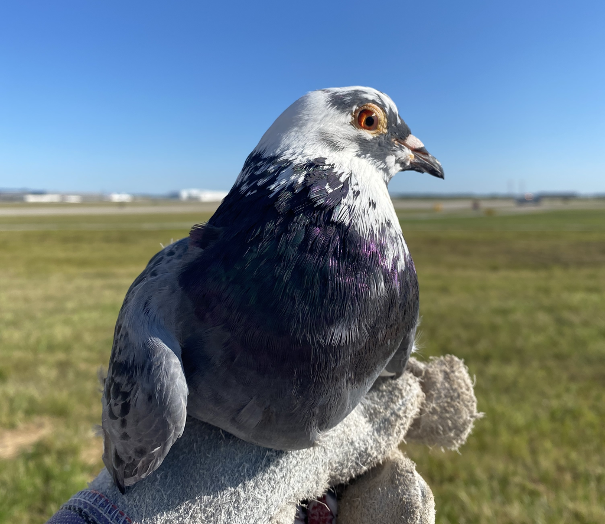

**Figure 1.** A beautiful rock pigeon caught at DTW. The unique, speckled plumage earned this bird the name Patches O’Houlihan.

## Methods

### Data Collection

There were 20 independent, random observations of birds in the pigeon coop. Each observation included counting the number of pigeons perched on wood perches and the number of pigeons perched on metal perches. Note that in the coop, there were 2 wooden perches available and 5 metal perches available. These perches were spaced out relatively evenly and at comparable heights.

### Analysis

First, count data were standardized to account for unequal perch availability (2 wooden perches versus 5 metal). Specifically, count data were standardized to the number of birds per perch type, then we calculated summary statistics and compared means. We used one-sample t-tests to estimate the mean number of pigeons per perch type and their associated 95% confidence intervals. Means were considered different if confidence intervals did not overlap.

### Data

Here (below) were what the raw count data looked like; and the standardized count data (i.e., transformed raw counts to birds per perch type).

```
##    Wood Metal
## 1     5     1
## 2     5     3
## 3     5     6
## 4     2     0
## 5     5     3
## 6     3     1
## 7     3     0
## 8     3     1
## 9     6     0
## 10    2     1
## 11    2     3
## 12    4     4
## 13    6     6
## 14    4     4
## 15    5     4
## 16    6     0
## 17    6     4
## 18    6     3
## 19    2     1
## 20    3     1
```

```
##    Standardized_Wood Standardized_Metal
## 1                2.5                0.2
## 2                2.5                0.6
## 3                2.5                1.2
## 4                1.0                0.0
## 5                2.5                0.6
## 6                1.5                0.2
## 7                1.5                0.0
## 8                1.5                0.2
## 9                3.0                0.0
## 10               1.0                0.2
## 11               1.0                0.6
## 12               2.0                0.8
## 13               3.0                1.2
## 14               2.0                0.8
## 15               2.5                0.8
## 16               3.0                0.0
## 17               3.0                0.8
## 18               3.0                0.6
## 19               1.0                0.2
## 20               1.5                0.2
```

## Results & Discussion

We found that the number of pigeons per wooden perch was almost five times higher than the number per metal perch (Figure 2). More specifically, wooden perches supported an estimated mean of approximately 2.1 pigeons per perch (95% CI ≈ 1.72–2.43), whereas metal perches supported only 0.46 pigeons per perch on average (95% CI ≈ 0.28–0.64). Because these intervals do not overlap, the results indicate a clear and statistically robust difference in perch selection.

Although more metal perches than wooden perches were available in the coop, the standardized counts revealed that pigeons used wooden perches at disproportionately higher rates. The difference between perch types was large in magnitude and consistent across sampling events, supporting the conclusion that pigeons preferred flat wooden perches to round metal perches.

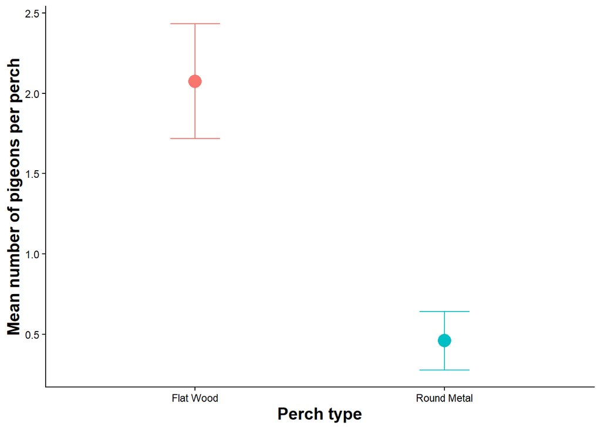

**Figure 2.** Despite there being less wooden perches compared to metal (2 and 5, respectively), pigeons per wooden perch were almost 5 times higher compared to metal (Wood: Mean = 2.075, 95% CI = 1.717, 2.433; Metal: Mean = 0.460, 95% CI = 0.278, 0.642). These results demonstrate a statistically significant difference between perches, suggesting flat perch sites are important to rock pigeons.